# Exploration of wild-type and transgenic variants of Arabidopsis Thaliana

Project Aims and Data Set Introduction

This project aims to independently investigate the gene expression data published by Cabrales-Orona et al. (2026) using differential expression analysis and original visualizations. My analysis focuses on comparing gene expression between wild-type plants and a transgenic line (Line 12) at matched time points to identify genes associated with heat tolerance. Below I outline the two main goals driving this exploration.

Differential Expression Analysis

The primary goal of this dashboard is to identify genes that are differentially expressed between wild-type *Arabidopsis* and the transgenic Line 12 under heat shock conditions. Using DESeq2, I compare gene expression at the 1-hour heat shock time point to identify which genes are significantly up or downregulated in the transgenic line, and what biological processes those genes are involved in.

Heat Stress Response Across Time

The secondary goal is to explore how gene expression changes across multiple time points within each line. By visualizing expression patterns at 1 hour, 5.5 hours, 11 hours, and after recovery, I aim to better understand how *Arabidopsis* adapts its transcriptional response to sustained heat stress, and whether the transgenic line responds differently over time compared to wild-type plants.

Data Visualization

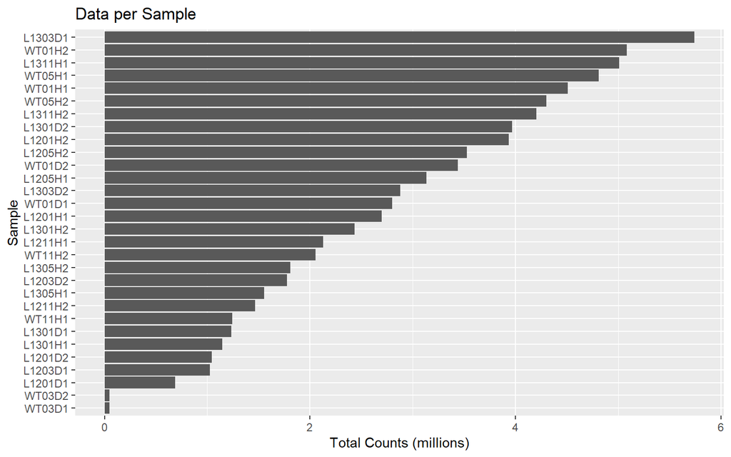

Here we start our data exploration with visualizing the total sequencing depth across all 30 samples of *Arabidopsis thaliana*. This tells us something important there is a drop off of data points for some lines and most notably a harsh drop off for two lines specifically WT03D2 and WT03D1.

Investigating Data Across Samples

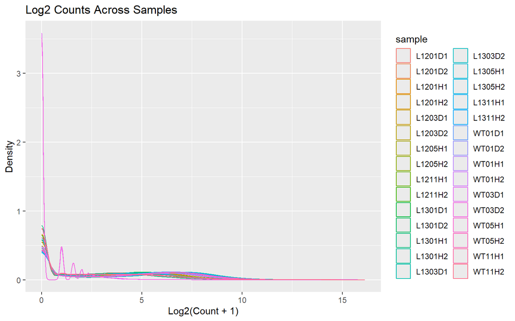

PCA of the DESeq2 Object

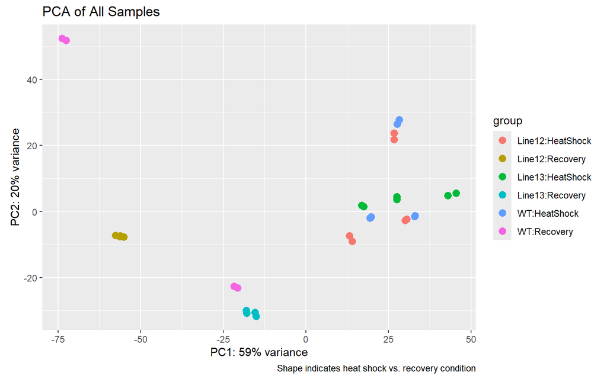

Here we are plotting the PCA of all the samples in the dataset after we filtered the data. This shows us the amount of data that each line in heat shock or recovery contributes to the variance in the data.

Differential Expression Analysis

```
out of 19575 with nonzero total read count
adjusted p-value < 0.1
LFC > 0 (up)       : 670, 3.4%
LFC < 0 (down)     : 485, 2.5%
outliers [1]       : 0, 0%
low counts [2]     : 5313, 27%
(mean count < 17)
[1] see 'cooksCutoff' argument of ?results
[2] see 'independentFiltering' argument of ?results
```

To identify genes that respond differently to heat stress between wild-type *Arabidopsis* and the transgenic Line 12, we use DESeq2, a statistical framework designed specifically for RNA sequence count data. Our analysis subsets the data to only the 1 hour heat shock time point which gives us the cleanest treated vs. control comparison. Wild-type is set as the reference group, so fold changes represent expression in Line 12 relative to WT. Genes with an adjusted p-value below 0.05 and a log2 fold change greater than 1 in either direction are considered statistically significant.

Volcano Plot: Line 12 vs Wild-Type

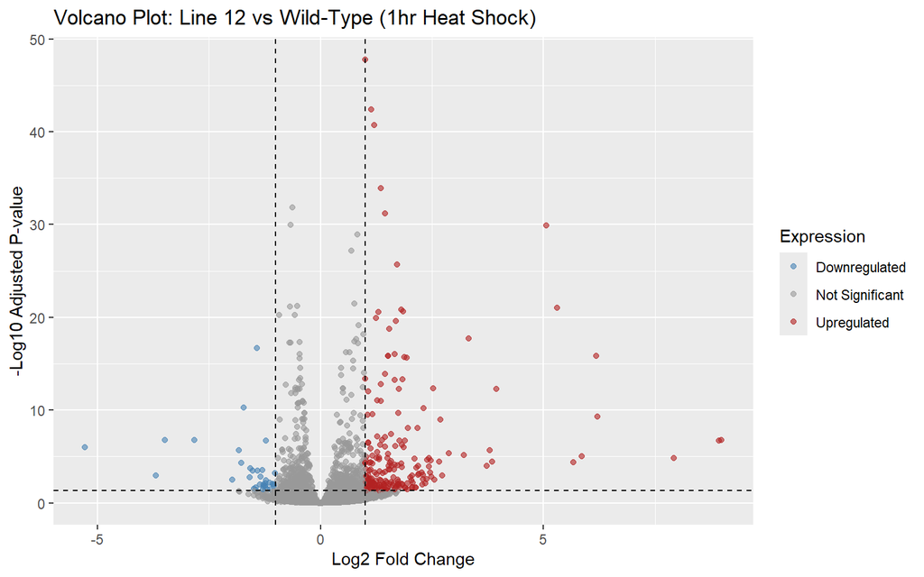

The volcano plot visualizes the results of the differential expression analysis. Each point represents a single gene. The x-axis shows the log2 fold change, how much higher or lower a gene’s expression is in Line 12 compared to wild-type. The y-axis shows statistical significance as -log10 of the adjusted p-value, meaning points higher up are more statistically significant. Red points in the upper right are significantly upregulated in Line 12, blue points in the upper left are significantly downregulated, and grey points did not meet our significance thresholds. The dashed lines mark the fold change (±1) and significance (padj = 0.05) thresholds.

Top Genes

```
 [1] "AT3G23810"   "AT3G17390"   "AT2G36880"   "AT1G06000"   "AT1G06002"
 [6] "AT4G33790"   "AT5G15490"   "AT5G37940"   "AT1G17745"   "AT5G22580"
[11] "AT4G21650"   "AT3G29360"   "AT5G23860"   "AT2G25900"   "AT5G60490"
[16] "AT5G20630"   "AT2G36570"   "AT2G06950"   "AT2G06950.1" "AT1G57750"
[21] "AT1G55330"   "AT5G17420"   "AT4G12730"   "AT2G14890"   "AT5G44030"
[26] "AT3G12110"   "AT2G29550"   "AT2G40480"   "AT1G06350"   "AT2G38080"
[31] "AT5G19780"   "AT2G07731"   "AT2G20610"   "AT4G19430"   "AT1G62360"
[36] "AT5G10770"   "AT1G65060"   "AT5G19770"   "AT5G42180"   "AT1G22530"
```

Here we construct a new DESeq2 object using only the WT and Line 12 samples collected during active heat shock, with recovery samples excluded. differing from the volcano plot analysis we incorporate both line and time point as variables, allowing us to capture expression dynamics across 1, 5.5, and 11 hours of heat stress. We then extract the top 40 most statistically significant genes identified in the previous analysis as the basis for our time course visualization.

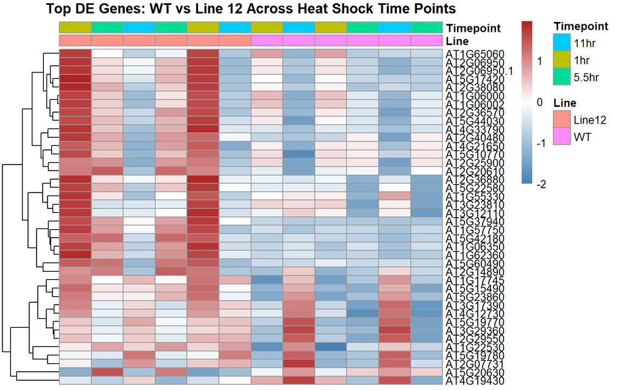

The heatmap above visualizes the expression patterns of the top 40 differentially expressed genes across all heat shock time points in WT and Line 12 plants. Each row represents a gene and each column represents a sample, with red indicating higher relative expression and blue indicating lower relative expression. Genes are clustered by similarity in expression pattern, revealing groups of genes that respond to heat stress in a coordinated manner. By comparing columns across time points and between lines, we can see whether the transcriptional differences between wild-type and Line 12 are consistent throughout heat exposure or change as stress is sustained.

Resources and Citations

This project utilized resources primarily from two academic papers. If you are interested in anything you see on this dashboard look into the two papers cited below.

1. Cabrales-Orona G, et al. (2026). Grain amaranth genes coding for an RNA-binding and a small, unknown function protein, respectively, enhance thermotolerance when overexpressed in Arabidopsis thaliana. Physiol Mol Biol Plants, 32(1):59–80. PMID: 41675614 1.2 The dataset used in the paper: NCBI Gene Expression Omnibus (GEO), accession GSE277320. https://www.ncbi.nlm.nih.gov/geo/query/acc.cgi?acc=GSE277320
2. Chen Y, Lun AT, Smyth GK. From reads to genes to pathways: differential expression analysis of RNA-Seq experiments using Rsubread and the edgeR quasi-likelihood pipeline. F1000Res. 2016 Jun 20;5:1438. doi: 10.12688/f1000research.8987.2. PMID: 27508061; PMCID: PMC4934518.